# Fundamentals of Programming 2026

Author

Berry Boessenkool;

Published

This is a markdown / github task in the course [FP26](https://open.hpi.de/learn/hpi-dh-fprog2026) with source code at the [repo](https://github.com/brry/FP26).  
*It is fine to not understand the R/Python code at this point - we’ll get to that throughout the course :)*

- Please first read the i.2 homework slide and follow the [installation guide](https://github.com/brry/fpsetup#software-installation-guide).
- Please **pull** before you work and again before you **push**!! We want to reduce version conflicts as much as possible.
- Include the generated md file (+ image and libs files) in your commit so that the website gets updated.
- Write an informative commit message.
- `Pull` before you `push` your commit. Yes, this instruction is repetitive. Experience teaches it is necessary. DO NOT UPLOAD YOUR CHANGES WITHOUT FIRST UPDATING THE CODE!

## Homework

Implement **one** of the ideas below, following the instructions above.  
To learn more markdown, create a copy of the file ([version at course start](https://github.com/brry/FP26/blob/40183444cc94076d9c0b2559d37a1a9bd45351e8/index.qmd) if wanted) in which you can implement many/all ideas. Each student should have some options available, so don’t push those changes.

**TipCompleted ideas**

- change the date format in the yaml header to include HH:mm after the day (*this one should be implemented early, please*)
- change this bullet list to checkboxes for ideas that are implemented
- link “version at course start” to the suitable github file history URL
- add some reasonable markdown code (e.g. strikethrough, link, reference, bold, cursive, …)
- in Rstudio: change the chunk output location setting to “console” (changes yaml header)
- make one single code chunk foldable (folded by default); leave all other chunks as is
- suppress the output of `updateRdwd` with a chunk option
- add a bit of text with the output of an inline code expression
- improve the python output to not be split up but appear after all code (with a chunk option)
- move done tasks to a nicely named collapsed section to declutter this overview
- add a `knitr::kable` with a small subset of the dataset (with proper package importing)
- format a plot as actual figures and add labels (chunk options)
- elsewehere in the text, add a reference to that figure
- change the date to the rendering time (note why in the commit - there is one particular reason)
- add a table of contents (yaml header option)
- set a custom theme or highlight style in the yaml header
- use the modern chunk option format (at chunk top, not inside {}) for labels + options
- add a footnote somewhere in the text
- add an image (e.g. a screenshot or the DWD logo) with alt text
- set global execution options in the yaml (e.g. `warning: false`) instead of per-chunk
- add `fig-width` / `fig-height` as global defaults in the yaml
- add margin content with `column: margin` on a chunk or text block

**Tipclick here for further ideas**

These suggestions are less applicable to the document at hand or not so interesting for learning the markdown basics

- use a tabset (`:::{.panel-tabset}`) to organise sections or outputs
- add cross-references between sections using `@sec-` labels
- cite scientific articles referring to a local bibliography file
- use a blockquote (`>`) for a fun or relevant quote about weather/data
- add an explanation why the code chunks in this particular document should not be cached
- use a meaningful multi-line commit message (subject + body) for a commit
- change some other document setting you like from [quarto.org](https://quarto.org/)
- revert / adapt a change someone made that you dislike (commit/PR discussion welcome!)
- tag a version with `git tag` after a meaningful milestone
- add a `.gitignore` entry for irrelevant output folders (e.g. `*_cache/`)
- enable `embed-resources: true` so the HTML renders as a single self-contained file
- improve a code chunk with some meaningful adaptation (this is not markdown related)
- use code annotation (`# <1>` style) to explain a line in a chunk without touching the code logic
- use a different style Quarto callout block for important info

## Version at the Course start

[version at course start](https://github.com/brry/FP26/commits/main/index.qmd)

## Check package availability

```python
import matplotlib, pandas
```

```r
if(!requireNamespace("rdwd", quietly=TRUE))
    install.packages("rdwd")
rdwd::updateRdwd(vignette=FALSE)
```

## Get weather data

download recent weather data using [rdwd](https://brry.github.io/rdwd/)[^1]

```r
library(rdwd)
link <- selectDWD("Potsdam", res="daily", var="kl", per="recent")
clim <- dataDWD(link, varnames=TRUE, force=24, quiet=TRUE)
```

```r
knitr::kable(
  head(clim[, c("MESS_DATUM", "TMK.Lufttemperatur")], 5),
  caption = "First five rows of Potsdam weather data"
)
```

First five rows of Potsdam weather data

| MESS_DATUM | TMK.Lufttemperatur |
| --- | --- |
| 2025-04-27 | 10.7 |
| 2025-04-28 | 13.6 |
| 2025-04-29 | 15.8 |
| 2025-04-30 | 16.5 |
| 2025-05-01 | 18.3 |

The dataset covers 550 days with a mean daily temperature of 12 °C.

Potsdam weather is boring **surprisingly interesting** once you *plot* it, thanks to open data from the [DWD](https://www.dwd.de).

Data source: DWD Climate Data Center.

[figure not shown]

Logo of the German Weather Service (DWD)

## Visualise recent temperature

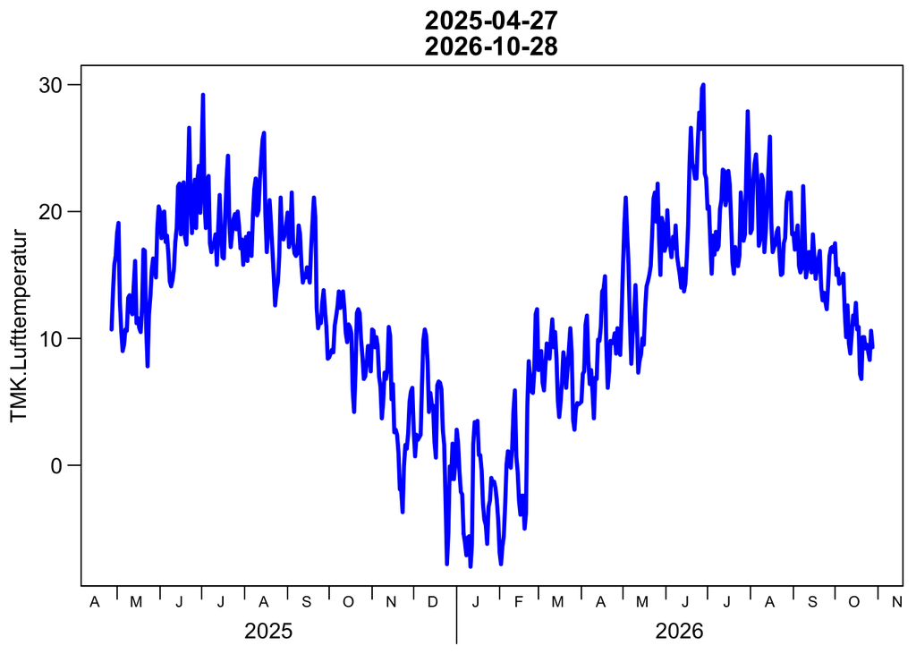

Figure 1: Recent daily temperature in Potsdam

```r
plotDWD(clim, "TMK.Lufttemperatur", main=range(clim$MESS_DATUM))
```

The recent temperature pattern is shown in Figure 1.

## Transfer to Python

```
Dataset shape: 550 rows, 19 columns
array([[<Axes: title={'center': 'FX.Windspitze'}>,
        <Axes: title={'center': 'FM.Windgeschwindigkeit'}>,
        <Axes: title={'center': 'RSK.Niederschlagshoehe'}>],
       [<Axes: title={'center': 'SDK.Sonnenscheindauer'}>,
        <Axes: title={'center': 'NM.Bedeckungsgrad'}>,
        <Axes: title={'center': 'VPM.Dampfdruck'}>],
       [<Axes: title={'center': 'PM.Luftdruck'}>,
        <Axes: title={'center': 'TMK.Lufttemperatur'}>,
        <Axes: title={'center': 'UPM.Relative_Feuchte'}>],
       [<Axes: title={'center': 'TXK.Lufttemperatur_Max'}>,
        <Axes: title={'center': 'TNK.Lufttemperatur_Min'}>,
        <Axes: title={'center': 'TGK.Lufttemperatur_5cm_min'}>]],
      dtype=object)
```

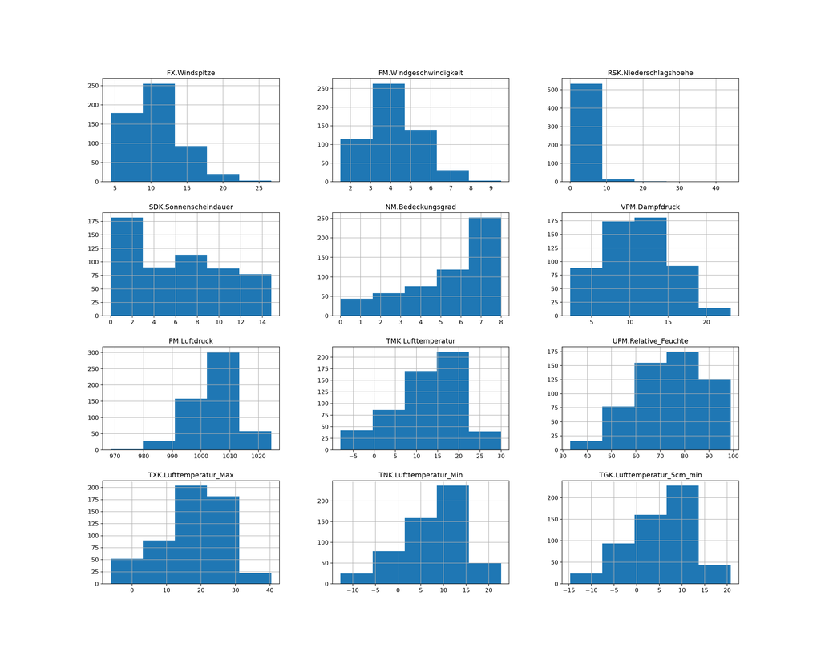

```python
clim_py = r.clim
print(f"Dataset shape: {clim_py.shape[0]} rows, {clim_py.shape[1]} columns")
clim_py = clim_py.select_dtypes(include=['float64', 'int64'])
clim_py.hist(figsize=(20, 16), bins=5)
```

## Summary statistics

**Show summary statistics code**

```python
# Calculate and display some basic statistics
print("\n=== Summary Statistics for Temperature ===")
```

```
=== Summary Statistics for Temperature ===
```

**Show summary statistics code**

```python
temp_stats = clim_py['TMK.Lufttemperatur'].describe()
print(temp_stats)
```

```
count    550.000000
mean      12.365273
std        7.712865
min       -8.000000
25%        7.500000
50%       13.700000
75%       18.100000
max       30.000000
Name: TMK.Lufttemperatur, dtype: float64
```

## Footnotes

[^1]: The German Weather Service (DWD) provides free access to weather data.